| title: “Individual differences in statistical learning” |
| --- |
| output: html_notebook |

# Preparation

## R packages:

```r
library(tidyverse)
library(broom)
library(psych)
library(EFAtools)
library(lavaan)
library(ClustOfVar)
library(semTools)
library(semPlot)
library(tidySEM)
```

## Data:

```r
df = df %>%
  mutate(
    processing_speed_visual_RT = -(processing_speed_visual_RT),
    processing_speed_visual_decision = -(processing_speed_visual_decision),
    processing_speed_auditory_RT = -(processing_speed_auditory_RT),
    simon_RT = -(simon_RT),
    simon_accuracy = -(simon_accuracy),
    stroop_RT = -(stroop_RT),
    stroop_accuracy = -(stroop_accuracy),
    selfpaced_gardenpath_target = -(selfpaced_gardenpath_target),
    selfpaced_violation_processing_target = -(selfpaced_violation_processing_target)
  )
```

# 1. Selecting reliable indices

Unidimensionality was assessed using Exploratory Factor Analysis (EFA) on individual items within the task index. Internal consistency was evaluated using the split-half method or omega coefficient where applicable, with a minimum reliability level set at 0.5 as the inclusion criterion.

For *grammatical sensitivity* and *pragmatic comprehension* indices, the item composition was modified to meet the criteria. Since these two indices consist of qualitatively different items, to prevent overfitting, we divided the sample into two halves. One half was used to select well-fitting items in the modified index, and the other half was employed to evaluate the new structure.

**Table 1**

*Reliability of indices of the original dataset*

| group | task | index | reliability type | reliability value | unidimensionality | suitable |
| --- | --- | --- | --- | --- | --- | --- |
| COG | processing speed | visual reaction time | split-half* | 0.957 | n.a. | yes |
| COG | processing speed | auditory reaction time | split-half* | 0.956 | n.a. | yes |
| COG | processing speed | visual decision score | split-half* | 0.179 | n.a. | no |
| COG | processing speed | visual decision time | split-half* | 0.952 | n.a. | yes |
| COG | simon | simon RT | split-half* | 0.643 | n.a. | yes |
| COG | simon | simon accuracy | split-half* | 0.546 | n.a. | yes |
| COG | stroop | stroop RT | split-half* | 0.768 | n.a. | yes |
| COG | stroop | stroop accuracy | split-half* | 0.876 | n.a. | yes |
| COG | digit span | forward digit span | n.a. | n.a. | n.a. | yes |
| COG | digit span | backward digit span | n.a. | n.a. | n.a. | yes |
| COG | n-back | 1-back d-prime | split-half* | 0.807 | n.a. | yes |
| COG | n-back | 2-back d-prime | split-half* | 0.763 | n.a. | yes |
| COG | n-back | 3-back d-prime | split-half* | 0.691 | n.a. | yes |
| SL | speech segmentation | SEGM RT training | split-half* | 0.646 | n.a. | yes |
| SL | speech segmentation | SEGM RT TRN3-RND4 | split-half* | 0.768 | n.a. | yes |
| SL | speech segmentation | SEGM RT RND4-REC5 | split-half* | 0.778 | n.a. | yes |
| SL | speech segmentation | SEGM ACC training | split-half* | 0.855 | n.a. | yes |
| SL | speech segmentation | SEGM ACC TRN3-RND4 | split-half* | 0.850 | n.a. | yes |
| SL | speech segmentation | SEGM ACC RND4-REC5 | split-half* | 0.761 | n.a. | yes |
| SL | speech segmentation | SEGM 2AFC bigram | n.a. | n.a. | n.a. | yes |
| SL | speech segmentation | SEGM 2AFC trigram | n.a. | n.a. | n.a. | yes |
| SL | speech segmentation | SEGM production | n.a. | n.a. | n.a. | yes |
| SL | artificial grammar learning | AGL RT training | split-half* | 0.222 | n.a. | no |
| SL | artificial grammar learning | AGL RT TRN3-RND4 | split-half* | 0.270 | n.a. | no |
| SL | artificial grammar learning | AGL RT RND4-REC5 | split-half* | 0.247 | n.a. | no |
| SL | artificial grammar learning | AGL ACC training | split-half* | 0.634 | n.a. | yes |
| SL | artificial grammar learning | AGL ACC TRN3-RND4 | split-half* | 0.380 | n.a. | no |
| SL | artificial grammar learning | AGL ACC RND4-REC5 | split-half* | 0.390 | n.a. | no |
| SL | artificial grammar learning | AGL 2AFC sentence | n.a. | n.a. | n.a. | yes |
| SL | artificial grammar learning | AGL 2AFC phrase | n.a. | n.a. | n.a. | yes |
| SL | artificial grammar learning | AGL production | n.a. | n.a. | n.a. | yes |
| LANG | predictive sentence processing | predictive sentence processing RT | split-half* | 0.853 | n.a. | yes |
| LANG | predictive sentence processing | predictive sentence processing accuracy | split-half* | 0.585 | n.a. | yes |
| LANG | KOBAK | pragmatic comprehension | omega | 0.630 | 1 | yes |
| LANG | grammatical sensitivity | grammatical sensitivity | omega | 0.676 | 1 | yes |
| LANG | self-paced reading | garden path - target | omega | 0.506 | 1 | yes |
| LANG | self-paced reading | garden path - plus one | omega | -0.060 | 0 | no |
| LANG | self-paced reading | past participle garden path - target | omega | 0.270 | 0 | no |
| LANG | self-paced reading | past participle garden path - plus one | omega | 0.140 | 0 | no |
| LANG | self-paced reading | object relative clause processing - target | omega | -0.030 | 1 | no |
| LANG | self-paced reading | object relative clause processing - plus one | omega | 0.576 | 0 | no |
| LANG | self-paced reading | sentence violation processing - target | omega | 0.681 | 1 | yes |
| LANG | self-paced reading | sentence violation processing - plus one | omega | 0.391 | 0 | no |
| LANG | one-minute reading | one-minute reading | n.a. | n.a. | n.a. | yes |

*Note.* *: Reported split-half reliabilities are the mean of 100 iterations, Spearman-Brown corrected at each iteration.

# 2. Latent variable identification

## 2.1. Summary for the process of latent variable identification

(See details below)

To identify latent variables, we initially categorised the measurement indices into three designated domains: the *statistical learning* (SL) domain, the *general cognitive* (COG) domain, and the *language* (LANG) domain (see Table 1).

As a next step, exploratory factor analyses (EFAs) were conducted within each domain, following these procedures:

1. **KMO test**: Using the Kaiser-Meyer-Olkin test, we assessed the measures of sampling adequacy (MSA) for the indices. Subsequently, indices with unsatisfactory fit for EFA (MSA < 0.6) were excluded.
2. **Bartlett’s test**: Secondly, Bartlett’s test of sphericity was employed, with the significance level indicating a suitable fit for EFA.
3. **Parallel analysis**: To determine the number of factors in each domain, Horn’s parallel analysis was used. This method compares eigenvalues derived from the data matrix to those from a Monte Carlo simulated matrix generated from random data of the same size.
4. **Exploratory factor analysis**: After determining the number of factors, exploratory factor analysis was conducted using maximum likelihood as the factoring method and promax (oblique) rotation. Missing values were imputed using the mean. Based on factor loadings and uniqueness observed in each index, we refined our model.
5. **Hierarchical cluster analysis**: To validate EFA results, hierarchical cluster analyses were performed. The stability of partitions from a hierarchy of variables was evaluated using a bootstrapping method (n=100). Based on the mean adjusted Rand criterion, we examined local maximums regarding the potential number of clusters and selected the one supported by our theoretical considerations if necessary. We then proceeded with k-means clustering of variables, resulting in the identification of latent variables.
6. **Confirmatory factor analysis**: In the final step, we validated the structure through confirmatory factor analysis. Analyses were conducted using the Robust Maximum Likelihood method, with missing values imputed by the Maximum Likelihood method. Final models were refined if necessary.

During these steps, seven indices were removed from the initial 32 indices for not meeting the KMO test criterion, and two additional indices were dropped due to model refinement. Thus, the final data set included 23 indices from 12 different tasks (Table 2).

## 2.2. Latent variables in statistical learning domain

**Kaiser-Meyer-Olkin test**:

```
## ℹ 'x' was not a correlation matrix. Correlations are found from entered raw data.
```

```
##
## ── Kaiser-Meyer-Olkin criterion (KMO) ──────────────────────────────────────────
##
## ✖ The overall KMO value for your data is miserable.
##   These data are hardly suitable for factor analysis.
##
##   Overall: 0.551
##
##   For each variable:
##   SEGM_RT_training  SEGM_RT_TRN3_RND4  SEGM_RT_RND4_REC5  SEGM_ACC_training
##              0.555              0.530              0.596              0.381
## SEGM_ACC_TRN3_RND4 SEGM_ACC_RND4_REC5   SEGM_2AFC_bigram  SEGM_2AFC_trigram
##              0.453              0.388              0.585              0.708
##    SEGM_production   AGL_ACC_training    AGL_2AFC_phrase  AGL_2AFC_sentence
##              0.756              0.419              0.604              0.655
##     AGL_production
##              0.645
```

Then, KMO test was repeated.

```
## ℹ 'x' was not a correlation matrix. Correlations are found from entered raw data.
```

```
##
## ── Kaiser-Meyer-Olkin criterion (KMO) ──────────────────────────────────────────
##
## ! The overall KMO value for your data is mediocre.
##   These data are probably suitable for factor analysis.
##
##   Overall: 0.615
##
##   For each variable:
##  SEGM_RT_training SEGM_RT_TRN3_RND4 SEGM_RT_RND4_REC5  SEGM_2AFC_bigram
##             0.581             0.545             0.603             0.595
## SEGM_2AFC_trigram   SEGM_production   AGL_2AFC_phrase AGL_2AFC_sentence
##             0.705             0.831             0.604             0.703
##    AGL_production
##             0.642
```

The reaction time based indices showed poor fit (< 0.6), however, we did not omit them for their possible exploratory power. Instead, we performed two separate analysis with only the reaction time based variables and the remaining ones.

### 2.2.1. RT variables

**Bartlett’s test**:

```
## ℹ 'x' was not a correlation matrix. Correlations are found from entered raw data.
```

```
##
## ✔ The Bartlett's test of sphericity was significant at an alpha level of .05.
##   These data are probably suitable for factor analysis.
##
##   𝜒²(3) = 799.62, p < .001
```

**Parallel analysis**:

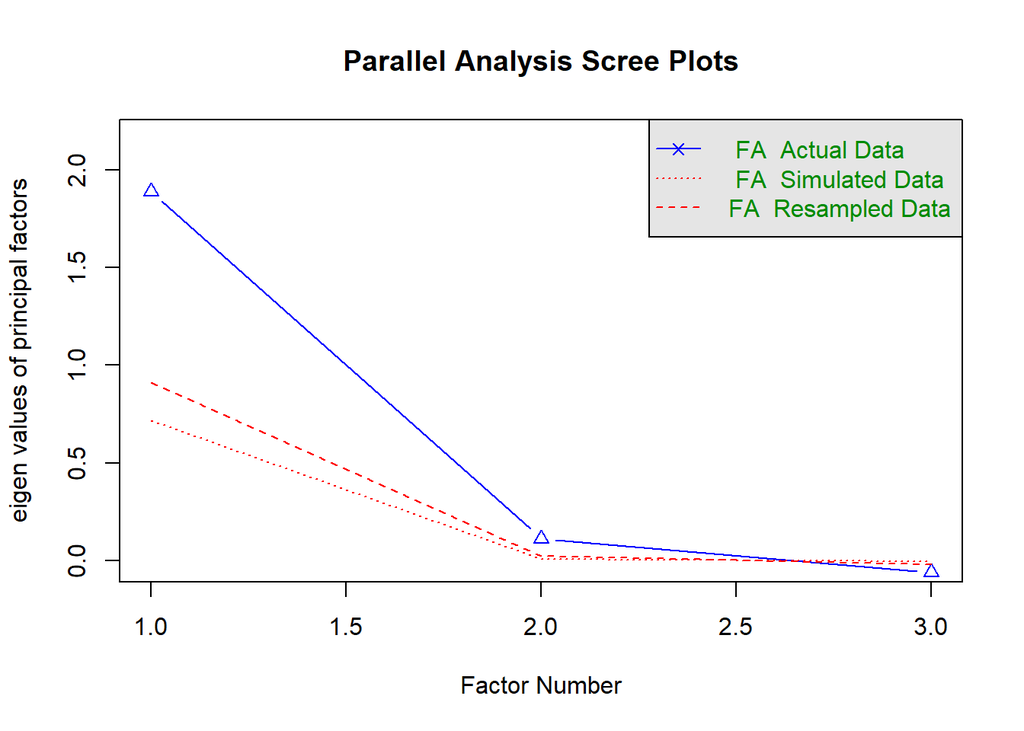

```
## Parallel analysis suggests that the number of factors =  2  and the number of components =  NA
```

**Exploratory factor analysis**:

```
##
## Factor analysis with Call: fa(r = ., nfactors = 1, rotate = "Promax", scores = "regression",
##     missing = TRUE, impute = "mean", fm = "ml", use = "pairwise",
##     cor = "cor")
##
## Test of the hypothesis that 1 factor is sufficient.
## The degrees of freedom for the model is 0  and the objective function was  0.05
## The number of observations was  608  with Chi Square =  28.44  with prob <  NA
##
## The root mean square of the residuals (RMSA) is  0.06
## The df corrected root mean square of the residuals is  NA
##
## Tucker Lewis Index of factoring reliability =  -Inf
```

```
##
## Loadings:
##                   ML1
## SEGM_RT_training  0.690
## SEGM_RT_TRN3_RND4 0.998
## SEGM_RT_RND4_REC5 0.685
##
##                  ML1
## SS loadings    1.941
## Proportion Var 0.647
```

```
## # A tibble: 3 × 2
##   names                   x
##   <chr>               <dbl>
## 1 SEGM_RT_training  0.523
## 2 SEGM_RT_TRN3_RND4 0.00499
## 3 SEGM_RT_RND4_REC5 0.530
```

### 2.2.2. Offline SL indices (non-RT indices)

**Bartlett’s test**:

```
## ℹ 'x' was not a correlation matrix. Correlations are found from entered raw data.
```

```
##
## ✔ The Bartlett's test of sphericity was significant at an alpha level of .05.
##   These data are probably suitable for factor analysis.
##
##   𝜒²(15) = 356.5, p < .001
```

**Parallel analysis**:

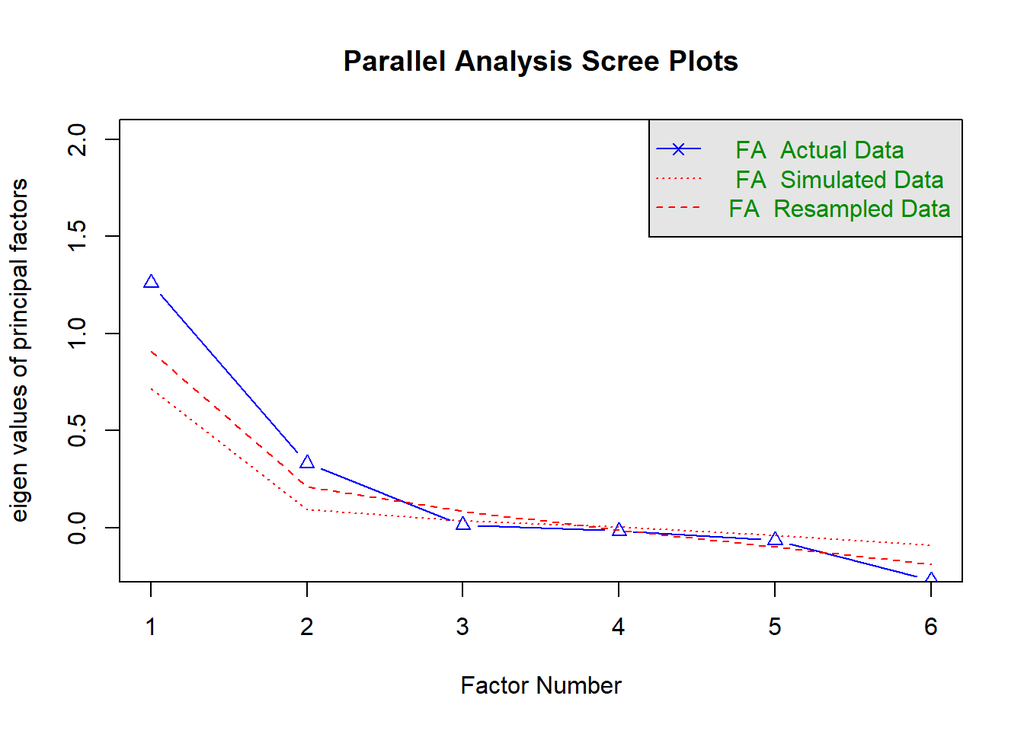

```
## Parallel analysis suggests that the number of factors =  2  and the number of components =  NA
```

Parallel analysis indicates 2 factors.

**Exploratory factor analysis**:

```
##
## Factor analysis with Call: fa(r = ., nfactors = 2, rotate = "Promax", scores = "regression",
##     missing = TRUE, impute = "mean", fm = "ml", use = "pairwise",
##     cor = "cor")
##
## Test of the hypothesis that 2 factors are sufficient.
## The degrees of freedom for the model is 4  and the objective function was  0.02
## The number of observations was  608  with Chi Square =  9.05  with prob <  0.06
##
## The root mean square of the residuals (RMSA) is  0.02
## The df corrected root mean square of the residuals is  0.05
##
## Tucker Lewis Index of factoring reliability =  0.944
## RMSEA index =  0.046  and the 10 % confidence intervals are  0 0.086
## BIC =  -16.59
##  With factor correlations of
##      ML1  ML2
## ML1 1.00 0.39
## ML2 0.39 1.00
```

```
##
## Loadings:
##                   ML1    ML2
## SEGM_2AFC_bigram   0.316
## SEGM_2AFC_trigram  1.020
## SEGM_production    0.150  0.336
## AGL_2AFC_phrase           0.442
## AGL_2AFC_sentence         0.700
## AGL_production            0.562
##
##                  ML1   ML2
## SS loadings    1.173 1.122
## Proportion Var 0.196 0.187
## Cumulative Var 0.196 0.382
```

```
## # A tibble: 6 × 2
##   names                   x
##   <chr>               <dbl>
## 1 SEGM_2AFC_bigram  0.881
## 2 SEGM_2AFC_trigram 0.00500
## 3 SEGM_production   0.825
## 4 AGL_2AFC_phrase   0.826
## 5 AGL_2AFC_sentence 0.543
## 6 AGL_production    0.679
```

### 2.2.3. Final model for statistical learning variables

Since the 2-factor model showed a complex structure, we proceeded with hierarchical cluster analysis to reveal potential single-variable factors.

**Hierarchical cluster analysis**:

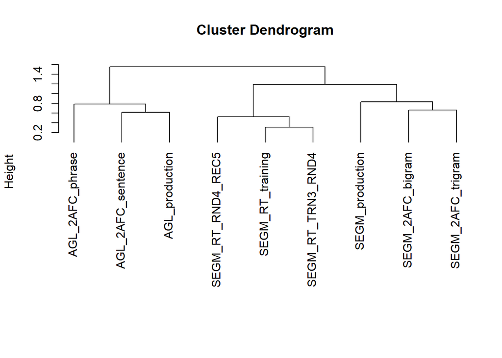

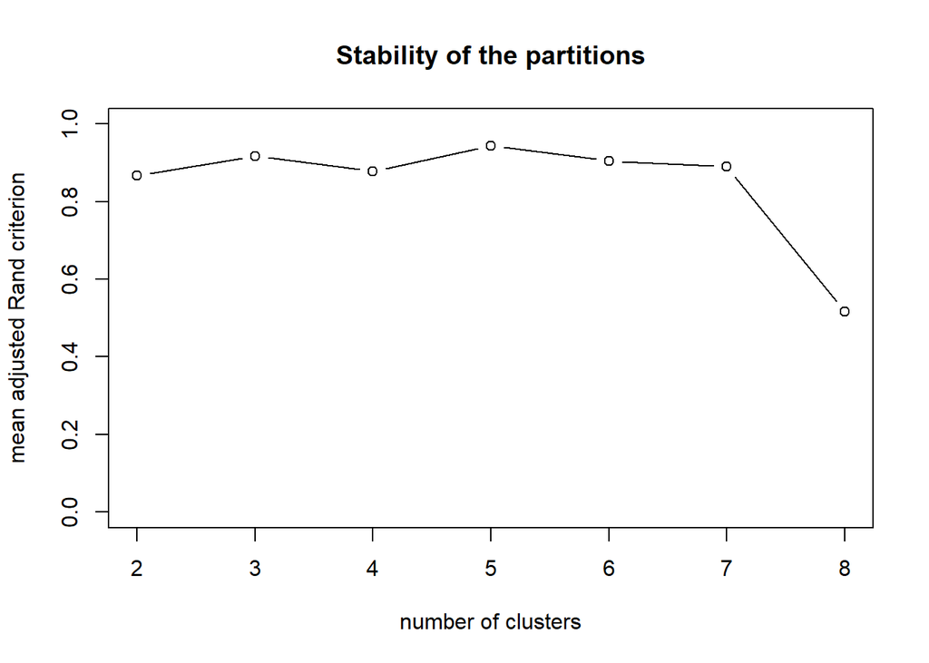

Since the Rand criterion shows that there is two local maxima (at 3 and 5) regarding the number of clusters, we selected the greater number to get a more detailed analysis.

**K-means cluster analysis**:

```
##
## Call:
## kmeansvar(X.quanti = ., init = 5, nstart = 1000)
##
## number of iterations:  1
##
## Data:
##    number of observations:  608
##    number of variables:  9
##    number of clusters:  5
##
## Cluster  1 :
##                   squared loading correlation
## SEGM_RT_TRN3_RND4            0.89       -0.94
## SEGM_RT_training             0.64       -0.80
## SEGM_RT_RND4_REC5            0.64       -0.80
##
##
## Cluster  2 :
##                   squared loading correlation
## SEGM_2AFC_trigram            0.67       -0.82
## SEGM_2AFC_bigram             0.67       -0.82
##
##
## Cluster  3 :
## squared loading     correlation
##               1               1
##
##
## Cluster  4 :
## squared loading     correlation
##               1               1
##
##
## Cluster  5 :
##                   squared loading correlation
## AGL_production               0.69       -0.83
## AGL_2AFC_sentence            0.69       -0.83
##
##
## Gain in cohesion (in %):  67.34
```

In conclusion, we used these 5 clusters of statistical learning variables to identify latent variables which later serve as predictors in the SEM models. We tested the robustness of the results with confirmatory factor analysis.

**Confirmatory factor analysis**:

**Model fits for CFA**:

```
## lavaan 0.6-19 ended normally after 51 iterations
##
##   Estimator                                         ML
##   Optimization method                           NLMINB
##   Number of model parameters                        35
##
##                                                   Used       Total
##   Number of observations                           386         608
##   Number of missing patterns                        11
##
## Model Test User Model:
##                                               Standard      Scaled
##   Test Statistic                                29.141      30.182
##   Degrees of freedom                                19          19
##   P-value (Chi-square)                           0.064       0.050
##   Scaling correction factor                                  0.966
##     Yuan-Bentler correction (Mplus variant)
##
## Model Test Baseline Model:
##
##   Test statistic                               559.241     481.464
##   Degrees of freedom                                36          36
##   P-value                                        0.000       0.000
##   Scaling correction factor                                  1.162
##
## User Model versus Baseline Model:
##
##   Comparative Fit Index (CFI)                    0.981       0.975
##   Tucker-Lewis Index (TLI)                       0.963       0.952
##
##   Robust Comparative Fit Index (CFI)                         0.983
##   Robust Tucker-Lewis Index (TLI)                            0.967
##
## Loglikelihood and Information Criteria:
##
##   Loglikelihood user model (H0)              -3119.162   -3119.162
##   Scaling correction factor                                  1.218
##       for the MLR correction
##   Loglikelihood unrestricted model (H1)      -3104.591   -3104.591
##   Scaling correction factor                                  1.129
```

[output cut: 77 more lines]

```
##                    Estimate  Std.Err  z-value  P(>|z|)   Std.lv  Std.all
##    .SEGM_RT_tranng    0.406    0.072    5.595    0.000    0.406    0.598
##    .SEGM_RT_TRN3_R   -0.165    0.101   -1.629    0.103   -0.165   -0.194
##    .SEGM_RT_RND4_R    0.532    0.100    5.344    0.000    0.532    0.608
##    .SEGM_2AFC_bgrm    0.857    0.091    9.387    0.000    0.857    0.850
##    .SEGM_2AFC_trgr    0.264    0.290    0.911    0.362    0.264    0.251
##    .SEGM_productin    0.000                               0.000    0.000
##    .AGL_2AFC_sntnc    0.585    0.105    5.568    0.000    0.585    0.600
##    .AGL_production    0.603    0.106    5.713    0.000    0.603    0.623
##    .AGL_2AFC_phras    0.000                               0.000    0.000
##     SL_RT             0.273    0.058    4.740    0.000    1.000    1.000
##     SL_tribi          0.152    0.074    2.059    0.040    1.000    1.000
##     SL_SEGM_prod      0.920    0.064   14.389    0.000    1.000    1.000
##     SL_AGL            0.390    0.112    3.492    0.000    1.000    1.000
##     SL_phr            0.966    0.080   12.034    0.000    1.000    1.000
```

In one case (*SEGM_2AFC_bigram [speech segmentation - SEGM 2AFC bigram]*), the unexplained variance was high (>0.65), however we kept it to assign convergent validity to the SL_trigram variable. We further excluded the *SEGM_AL_midRT_train [speech segmentation - SEGM RT training]* index to solve the Heywood case present in this factor.

The final grouping of the variables is:

1. **SEGM_RT**:
- SEGM_RT_TRN3_RND4 [speech segmentation - SEGM RT TRN3-RND4]
- SEGM_RT_RND4_REC5 [speech segmentation - SEGM RT RND4-REC5]
2. **SEGM_2_AFC**:
- SEGM_2AFC_trigram [speech segmentation - SEGM 2AFC trigram]
- SEGM_2AFC_bigram [speech segmentation - SEGM 2AFC bigram]
3. **SL_SEGM_production**:
- SEGM_production [speech segmentation - SEGM production]
4. **SL_AGL**:
- AGL_2AFC_sentence [artificial grammar learning - AGL 2AFC sentence ]
- AGL_production [artificial grammar learning - AGL production]
5. **AGL_phrase**:
- AGL_2AFC_phrase [artificial grammar learning - AGL 2AFC phrase]

## 2.3. Latent variables in general cognitive domain

**Kaiser-Meyer-Olkin test**:

```
## ℹ 'x' was not a correlation matrix. Correlations are found from entered raw data.
```

```
##
## ── Kaiser-Meyer-Olkin criterion (KMO) ──────────────────────────────────────────
##
## ! The overall KMO value for your data is mediocre.
##   These data are probably suitable for factor analysis.
##
##   Overall: 0.699
##
##   For each variable:
##       processing_speed_visual_RT     processing_speed_auditory_RT
##                            0.728                            0.712
## processing_speed_visual_decision               digit_span_forward
##                            0.811                            0.654
##              digit_span_backward              nback_1_back_dprime
##                            0.628                            0.766
##              nback_2_back_dprime              nback_3_back_dprime
##                            0.650                            0.672
##                        stroop_RT                  stroop_accuracy
##                            0.677                            0.594
##                         simon_RT                   simon_accuracy
##                            0.787                            0.455
```

Indices with unsatisfactory fit for EFA (MSA < 0.6) were excluded: * simon_accuracy [simon - accuracy] * stroop_accuracy [stroop - accuracy]

Then, KMO test was repeated.

```
## ℹ 'x' was not a correlation matrix. Correlations are found from entered raw data.
```

```
##
## ── Kaiser-Meyer-Olkin criterion (KMO) ──────────────────────────────────────────
##
## ✔ The overall KMO value for your data is middling.
##   These data are probably suitable for factor analysis.
##
##   Overall: 0.716
##
##   For each variable:
##       processing_speed_visual_RT     processing_speed_auditory_RT
##                            0.741                            0.709
## processing_speed_visual_decision               digit_span_forward
##                            0.803                            0.651
##              digit_span_backward              nback_1_back_dprime
##                            0.631                            0.776
##              nback_2_back_dprime              nback_3_back_dprime
##                            0.652                            0.674
##                        stroop_RT                         simon_RT
##                            0.732                            0.828
```

**Bartlett’s test**:

```
## ℹ 'x' was not a correlation matrix. Correlations are found from entered raw data.
```

```
##
## ✔ The Bartlett's test of sphericity was significant at an alpha level of .05.
##   These data are probably suitable for factor analysis.
##
##   𝜒²(45) = 1383.5, p < .001
```

**Parallel analysis**:

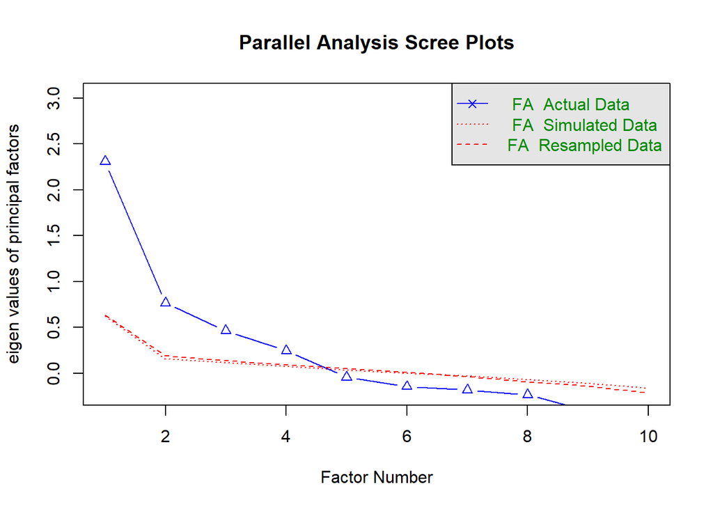

```
## Parallel analysis suggests that the number of factors =  4  and the number of components =  NA
```

**Exploratory factor analysis**:

```
##
## Factor analysis with Call: fa(r = ., nfactors = 4, rotate = "Promax", scores = "regression",
##     missing = TRUE, impute = "mean", fm = "ml", use = "pairwise",
##     cor = "cor")
##
## Test of the hypothesis that 4 factors are sufficient.
## The degrees of freedom for the model is 11  and the objective function was  0.04
## The number of observations was  608  with Chi Square =  22.31  with prob <  0.022
##
## The root mean square of the residuals (RMSA) is  0.01
## The df corrected root mean square of the residuals is  0.03
##
## Tucker Lewis Index of factoring reliability =  0.965
## RMSEA index =  0.041  and the 10 % confidence intervals are  0.015 0.066
## BIC =  -48.21
##  With factor correlations of
##      ML2  ML3  ML1  ML4
## ML2 1.00 0.34 0.17 0.36
## ML3 0.34 1.00 0.34 0.50
## ML1 0.17 0.34 1.00 0.38
## ML4 0.36 0.50 0.38 1.00
```

```
##
## Loadings:
##                                  ML2    ML3    ML1    ML4
## processing_speed_visual_RT               0.780
## processing_speed_auditory_RT             0.714        -0.148
## processing_speed_visual_decision         0.497         0.310
## digit_span_forward                       0.155  0.532
## digit_span_backward                             1.012
## nback_1_back_dprime               0.524                0.153
## nback_2_back_dprime               0.880
## nback_3_back_dprime               0.674               -0.120
## stroop_RT                               -0.111         0.649
## simon_RT                                 0.140         0.518
##
##                  ML2   ML3   ML1   ML4
## SS loadings    1.516 1.434 1.318 0.848
## Proportion Var 0.152 0.143 0.132 0.085
## Cumulative Var 0.152 0.295 0.427 0.512
```

```
## # A tibble: 10 × 2
##    names                                  x
##    <chr>                              <dbl>
##  1 processing_speed_visual_RT       0.364
##  2 processing_speed_auditory_RT     0.606
##  3 processing_speed_visual_decision 0.517
##  4 digit_span_forward               0.627
##  5 digit_span_backward              0.00500
##  6 nback_1_back_dprime              0.662
##  7 nback_2_back_dprime              0.272
##  8 nback_3_back_dprime              0.556
##  9 stroop_RT                        0.650
## 10 simon_RT                         0.634
```

For further analysis, we performed hierarchical variable clustering on the general cognitive variables as well.

**Hierarchical cluster analysis**:

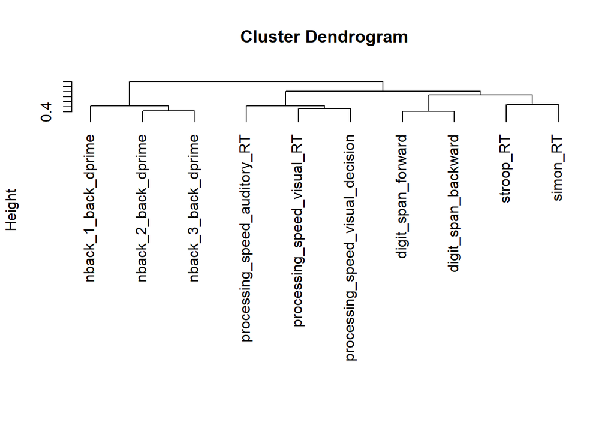

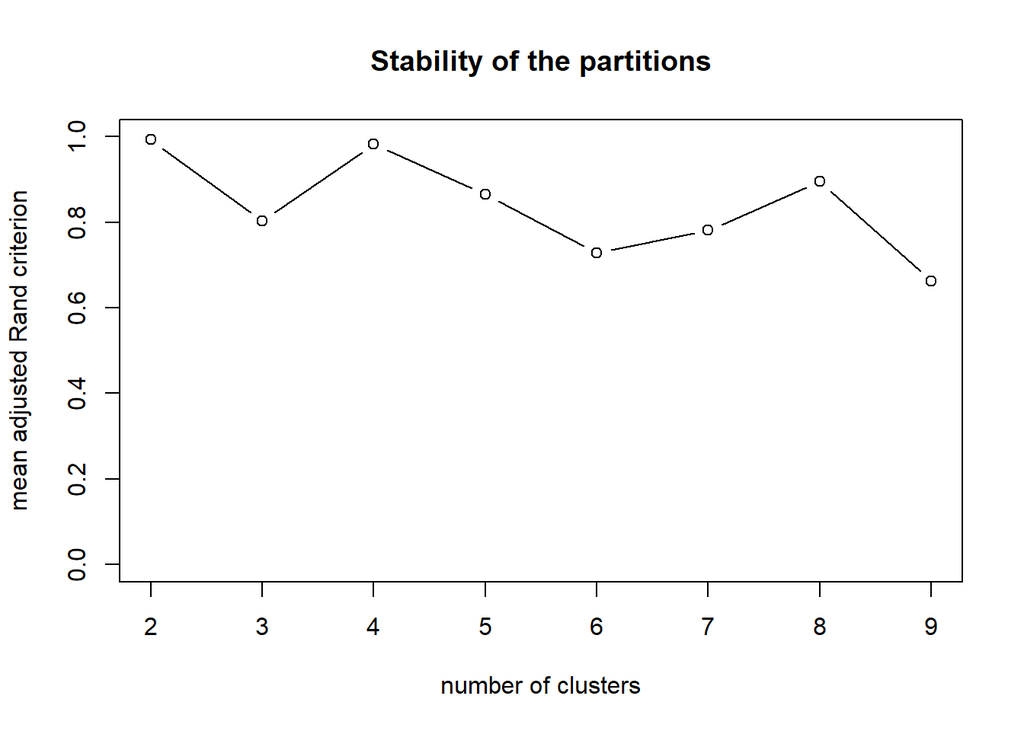

**K-means cluster analysis**:

```
##
## Call:
## kmeansvar(X.quanti = ., init = 4, nstart = 1000)
##
## number of iterations:  1
##
## Data:
##    number of observations:  608
##    number of variables:  10
##    number of clusters:  4
##
## Cluster  1 :
##                                  squared loading correlation
## processing_speed_visual_RT                  0.71       -0.85
## processing_speed_visual_decision            0.56       -0.78
## processing_speed_auditory_RT                0.56       -0.75
##
##
## Cluster  2 :
##                     squared loading correlation
## digit_span_forward             0.79       -0.89
## digit_span_backward            0.79       -0.89
##
##
## Cluster  3 :
##                     squared loading correlation
## nback_2_back_dprime            0.75       -0.86
## nback_3_back_dprime            0.63       -0.80
## nback_1_back_dprime            0.55       -0.74
##
##
## Cluster  4 :
##           squared loading correlation
## simon_RT             0.66        0.81
## stroop_RT            0.66        0.81
##
##
## Gain in cohesion (in %):  53.79
```

In conclusion, we have 4 clusters of cognitive variables:

1. **Processing Speed**:
- processing_speed_visual_RT [processing speed - visual reaction time]
- processing_speed_auditory_RT [processing speed - auditory reaction time]
- processing_speed_visual_decision [processing speed - visual decision time]
2. **Digit Span**:
- digit_span_forward [digit span - forward digit span]
- digit_span_backward [digit span - backward digit span]
3. **NBACK test**:
- nback_1_back_dprime [n-back - 1-back d-prime]
- nback_2_back_dprime [n-back - 2-back d-prime]
- nback_3_back_dprime [n-back - 3-back d-prime]
4. **Reaction Time**:
- stroop_RT [stroop - RT]
- simon_RT [simon - RT]

As the following step, we tested whether these factors shows an appropriate fit using CFA.

**Confirmatory factor analysis**:

**Model fits for CFA**:

```
## lavaan 0.6-19 ended normally after 43 iterations
##
##   Estimator                                         ML
##   Optimization method                           NLMINB
##   Number of model parameters                        36
##
##                                                   Used       Total
##   Number of observations                           588         608
##   Number of missing patterns                        40
##
## Model Test User Model:
##                                               Standard      Scaled
##   Test Statistic                                75.186      74.394
##   Degrees of freedom                                29          29
##   P-value (Chi-square)                           0.000       0.000
##   Scaling correction factor                                  1.011
##     Yuan-Bentler correction (Mplus variant)
##
## Model Test Baseline Model:
##
##   Test statistic                              1151.464    1024.285
##   Degrees of freedom                                45          45
##   P-value                                        0.000       0.000
##   Scaling correction factor                                  1.124
##
## User Model versus Baseline Model:
##
##   Comparative Fit Index (CFI)                    0.958       0.954
##   Tucker-Lewis Index (TLI)                       0.935       0.928
##
##   Robust Comparative Fit Index (CFI)                         0.952
##   Robust Tucker-Lewis Index (TLI)                            0.925
##
## Loglikelihood and Information Criteria:
##
##   Loglikelihood user model (H0)              -6235.268   -6235.268
##   Scaling correction factor                                  1.956
##       for the MLR correction
##   Loglikelihood unrestricted model (H1)      -6197.675   -6197.675
##   Scaling correction factor                                  1.534
```

[output cut: 73 more lines]

```
##                    Estimate  Std.Err  z-value  P(>|z|)   Std.lv  Std.all
##    .prcssng_sp__RT    0.275    0.060    4.593    0.000    0.275    0.339
##    .prcssng_spd_v_    0.470    0.076    6.173    0.000    0.470    0.443
##    .prcssng_sp__RT    0.623    0.078    7.999    0.000    0.623    0.693
##    .digt_spn_frwrd    0.395    0.078    5.071    0.000    0.395    0.401
##    .dgt_spn_bckwrd    0.440    0.076    5.821    0.000    0.440    0.435
##    .nbck_1_bck_dpr    0.640    0.050   12.768    0.000    0.640    0.665
##    .nbck_2_bck_dpr    0.260    0.068    3.819    0.000    0.260    0.286
##    .nbck_3_bck_dpr    0.560    0.062    8.970    0.000    0.560    0.558
##    .stroop_RT         0.672    0.121    5.541    0.000    0.672    0.729
##    .simon_RT          0.580    0.107    5.424    0.000    0.580    0.558
##     COG_PS            0.537    0.123    4.360    0.000    1.000    1.000
##     COG_DS            0.590    0.100    5.889    0.000    1.000    1.000
##     COG_nback         0.323    0.063    5.117    0.000    1.000    1.000
##     COG_RT            0.250    0.143    1.744    0.081    1.000    1.000
```

In three cases the unexplained variance is very high (>0.65). 1. First, we excluded the *nback_1_dprime* variable, since it does not carry more information compared to *nback_2_dprime* and *nback_3_dprime* variables both theoretically and measurement-wise. 2. Secondly, we split the *COG_RT factor* into two, since the *stroop* and *simon* tasks have potentially additional exploratory power in the model. 3. Thirdly, we split the *COG_PS factor* into two. (For detail see next section.)

To split the COG_PS into two factor, we performed two CFA analyses with nested models (*model_PS_01* and *model_PS_02*).

**First model / Model_PS_01**:

```
## lavaan 0.6-19 ended normally after 41 iterations
##
##   Estimator                                         ML
##   Optimization method                           NLMINB
##   Number of model parameters                        39
##
##                                                   Used       Total
##   Number of observations                           588         608
##   Number of missing patterns                        40
##
## Model Test User Model:
##                                               Standard      Scaled
##   Test Statistic                                44.698      41.625
##   Degrees of freedom                                15          15
##   P-value (Chi-square)                           0.000       0.000
##   Scaling correction factor                                  1.074
##     Yuan-Bentler correction (Mplus variant)
##
## Model Test Baseline Model:
##
##   Test statistic                              1005.137     864.414
##   Degrees of freedom                                36          36
##   P-value                                        0.000       0.000
##   Scaling correction factor                                  1.163
##
## User Model versus Baseline Model:
##
##   Comparative Fit Index (CFI)                    0.969       0.968
##   Tucker-Lewis Index (TLI)                       0.926       0.923
##
##   Robust Comparative Fit Index (CFI)                         0.965
##   Robust Tucker-Lewis Index (TLI)                            0.917
##
## Loglikelihood and Information Criteria:
##
##   Loglikelihood user model (H0)              -5640.834   -5640.834
##   Scaling correction factor                                  1.869
##       for the MLR correction
##   Loglikelihood unrestricted model (H1)      -5618.485   -5618.485
##   Scaling correction factor                                  1.648
```

[output cut: 85 more lines]

```
##    .prcssng_sp__RT    0.298    0.044    6.706    0.000    0.298    0.366
##    .prcssng_spd_v_    0.474    0.060    7.866    0.000    0.474    0.444
##    .prcssng_sp__RT    0.000                               0.000    0.000
##    .digt_spn_frwrd    0.432    0.078    5.531    0.000    0.432    0.438
##    .dgt_spn_bckwrd    0.403    0.081    4.962    0.000    0.403    0.398
##    .nbck_2_bck_dpr    0.395    0.137    2.878    0.004    0.395    0.437
##    .nbck_3_bck_dpr    0.429    0.151    2.832    0.005    0.429    0.426
##    .stroop_RT         0.000                               0.000    0.000
##    .simon_RT          0.000                               0.000    0.000
##     PS_01             0.517    0.114    4.550    0.000    1.000    1.000
##     PS_02             0.890    0.101    8.788    0.000    1.000    1.000
##     COG_DS            0.554    0.099    5.595    0.000    1.000    1.000
##     COG_nback         0.509    0.145    3.503    0.000    1.000    1.000
##     COG_stroop        0.926    0.219    4.224    0.000    1.000    1.000
##     COG_simon         1.042    0.199    5.237    0.000    1.000    1.000
```

**Second model / Model_PS_02**:

```
## lavaan 0.6-19 ended normally after 41 iterations
##
##   Estimator                                         ML
##   Optimization method                           NLMINB
##   Number of model parameters                        39
##
##                                                   Used       Total
##   Number of observations                           588         608
##   Number of missing patterns                        40
##
## Model Test User Model:
##                                               Standard      Scaled
##   Test Statistic                                22.637      21.557
##   Degrees of freedom                                15          15
##   P-value (Chi-square)                           0.092       0.120
##   Scaling correction factor                                  1.050
##     Yuan-Bentler correction (Mplus variant)
##
## Model Test Baseline Model:
##
##   Test statistic                              1005.137     864.414
##   Degrees of freedom                                36          36
##   P-value                                        0.000       0.000
##   Scaling correction factor                                  1.163
##
## User Model versus Baseline Model:
##
##   Comparative Fit Index (CFI)                    0.992       0.992
##   Tucker-Lewis Index (TLI)                       0.981       0.981
##
##   Robust Comparative Fit Index (CFI)                         0.995
##   Robust Tucker-Lewis Index (TLI)                            0.988
##
## Loglikelihood and Information Criteria:
##
##   Loglikelihood user model (H0)              -5629.803   -5629.803
##   Scaling correction factor                                  1.878
##       for the MLR correction
##   Loglikelihood unrestricted model (H1)      -5618.485   -5618.485
##   Scaling correction factor                                  1.648
```

[output cut: 85 more lines]

```
##    .prcssng_sp__RT    0.128    0.079    1.627    0.104    0.128    0.159
##    .prcssng_sp__RT    0.624    0.074    8.451    0.000    0.624    0.698
##    .prcssng_spd_v_    0.000                               0.000    0.000
##    .digt_spn_frwrd    0.422    0.075    5.630    0.000    0.422    0.428
##    .dgt_spn_bckwrd    0.413    0.077    5.392    0.000    0.413    0.408
##    .nbck_2_bck_dpr    0.398    0.119    3.337    0.001    0.398    0.441
##    .nbck_3_bck_dpr    0.425    0.134    3.177    0.001    0.425    0.421
##    .stroop_RT         0.000                               0.000    0.000
##    .simon_RT          0.000                               0.000    0.000
##     PS_01             0.680    0.137    4.971    0.000    1.000    1.000
##     PS_02             1.111    0.155    7.155    0.000    1.000    1.000
##     COG_DS            0.564    0.096    5.896    0.000    1.000    1.000
##     COG_nback         0.506    0.125    4.048    0.000    1.000    1.000
##     COG_stroop        0.925    0.217    4.258    0.000    1.000    1.000
##     COG_simon         1.037    0.197    5.263    0.000    1.000    1.000
```

Based on the two models, we concluded that *model_PS_02* indicates a better model considering four fit indices (TLI, CFI, SRMR, RMSEA) and the BIC. So for further analyses, we used the *processing_speed_visual_decision [processing speed - visual decision time]* index as a single-variable latent factor retaining the other two variables as the *PS factor*.

The final grouping of the variables is the following structure:

1. **Processing Speed**:
- processing_speed_visual_RT [processing speed - visual reaction time]
- processing_speed_auditory_RT [processing speed - auditory reaction time]
2. **Visual Decision Speed**:
- processing_speed_visual_decision [processing speed - visual decision time]
3. **Digit Span**:
- digit_span_forward [digit span - forward digit span]
- digit_span_backward [digit span - backward digit span]
4. **NBACK test**:
- nback_2_back_dprime [n-back - 2-back d-prime]
- nback_3_back_dprime [n-back - 3-back d-prime]
5. **Stroop task**:
- stroop_RT [stroop - RT]
6. **Simon task**:
- simon_RT [simon - RT]

## 2.4. Latent variables in language domain

**Kaiser-Meyer-Olkin test**:

```
## ℹ 'x' was not a correlation matrix. Correlations are found from entered raw data.
```

```
##
## ── Kaiser-Meyer-Olkin criterion (KMO) ──────────────────────────────────────────
##
## ✖ The overall KMO value for your data is miserable.
##   These data are hardly suitable for factor analysis.
##
##   Overall: 0.594
##
##   For each variable:
##               grammatical_sensitivity                    one_minute_reading
##                                 0.565                                 0.673
##               predictive_sent_proc_RT         predictive_sent_proc_accuracy
##                                 0.518                                 0.465
##           selfpaced_gardenpath_target selfpaced_violation_processing_target
##                                 0.617                                 0.623
##               pragmatic_comprehension
##                                 0.620
```

We excluded the *predictive_sent_proc_accuracy [predictive sentence processing - accuracy]* index which showed unacceptable KMO values (< 0.5).

```
## ℹ 'x' was not a correlation matrix. Correlations are found from entered raw data.
```

```
##
## ── Kaiser-Meyer-Olkin criterion (KMO) ──────────────────────────────────────────
##
## ! The overall KMO value for your data is mediocre.
##   These data are probably suitable for factor analysis.
##
##   Overall: 0.624
##
##   For each variable:
##               grammatical_sensitivity                    one_minute_reading
##                                 0.613                                 0.670
##               predictive_sent_proc_RT           selfpaced_gardenpath_target
##                                 0.594                                 0.601
## selfpaced_violation_processing_target               pragmatic_comprehension
##                                 0.628                                 0.631
```

**Parallel analysis**:

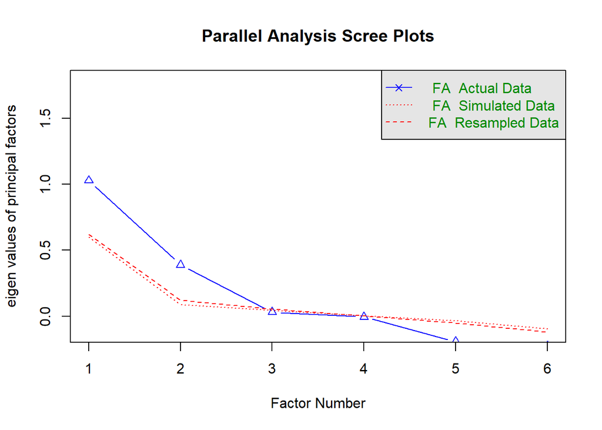

```
## Parallel analysis suggests that the number of factors =  2  and the number of components =  NA
```

Parallel analysis indicates 2 factors emerging.

**Exploratory factor analysis**:

```
##
## Factor analysis with Call: fa(r = ., nfactors = 2, rotate = "Promax", scores = "regression",
##     missing = TRUE, impute = "mean", fm = "ml", use = "pairwise",
##     cor = "cor")
##
## Test of the hypothesis that 2 factors are sufficient.
## The degrees of freedom for the model is 4  and the objective function was  0.02
## The number of observations was  608  with Chi Square =  12.06  with prob <  0.017
##
## The root mean square of the residuals (RMSA) is  0.03
## The df corrected root mean square of the residuals is  0.05
##
## Tucker Lewis Index of factoring reliability =  0.881
## RMSEA index =  0.058  and the 10 % confidence intervals are  0.022 0.096
## BIC =  -13.58
##  With factor correlations of
##      ML1  ML2
## ML1 1.00 0.32
## ML2 0.32 1.00
```

```
##
## Loadings:
##                                       ML1    ML2
## grammatical_sensitivity                       0.539
## one_minute_reading                     0.456
## predictive_sent_proc_RT                       0.410
## selfpaced_gardenpath_target            0.620
## selfpaced_violation_processing_target  0.594
## pragmatic_comprehension                       0.471
##
##                  ML1   ML2
## SS loadings    0.947 0.693
## Proportion Var 0.158 0.115
## Cumulative Var 0.158 0.273
```

```
## # A tibble: 6 × 2
##   names                                     x
##   <chr>                                 <dbl>
## 1 grammatical_sensitivity               0.720
## 2 one_minute_reading                    0.763
## 3 predictive_sent_proc_RT               0.835
## 4 selfpaced_gardenpath_target           0.639
## 5 selfpaced_violation_processing_target 0.642
## 6 pragmatic_comprehension               0.775
```

Since the 2-factor model showed a complex structure, we proceeded with hierarchical cluster analysis to reveal potential single-variable factors.

**Hierarchical cluster analysis**:

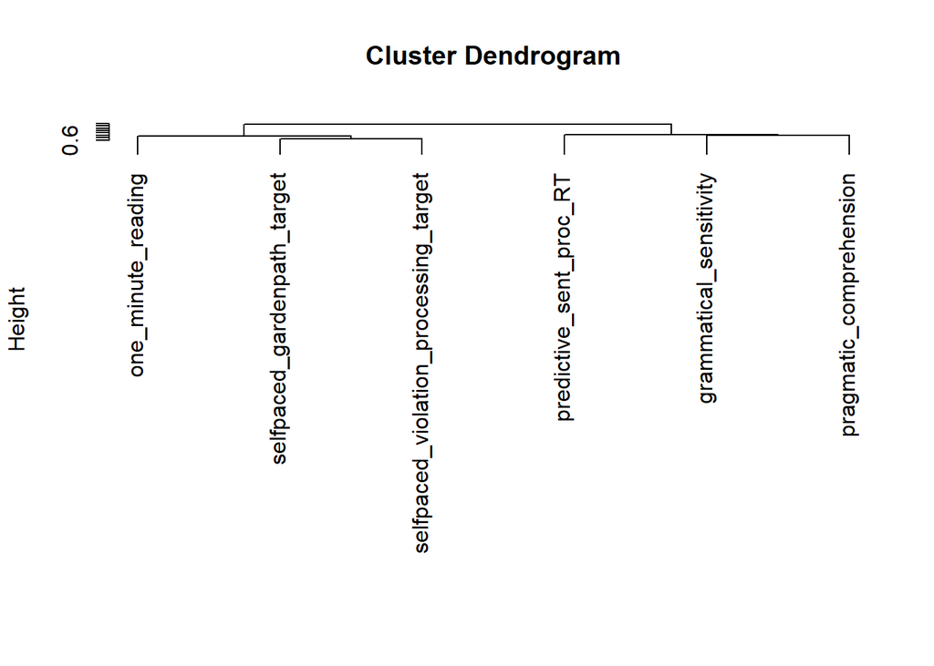

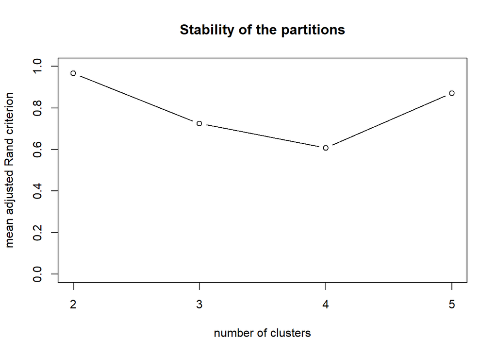

**K-means cluster analysis**:

```
##
## Call:
## kmeansvar(X.quanti = ., init = 5, nstart = 1000)
##
## number of iterations:  1
##
## Data:
##    number of observations:  608
##    number of variables:  6
##    number of clusters:  5
##
## Cluster  1 :
## squared loading     correlation
##               1               1
##
##
## Cluster  2 :
## squared loading     correlation
##               1               1
##
##
## Cluster  3 :
## squared loading     correlation
##               1               1
##
##
## Cluster  4 :
##                                       squared loading correlation
## selfpaced_violation_processing_target            0.68       -0.82
## selfpaced_gardenpath_target                      0.68       -0.82
##
##
## Cluster  5 :
## squared loading     correlation
##               1               1
##
##
## Gain in cohesion (in %):  85.03
```

As a next step, we tested whether these factors show appropriate fit using CFA.

**Confirmatory factor analysis**:

**Fit indices for CFA**:

```
## lavaan 0.6-19 ended normally after 25 iterations
##
##   Estimator                                         ML
##   Optimization method                           NLMINB
##   Number of model parameters                        24
##
##                                                   Used       Total
##   Number of observations                           530         608
##   Number of missing patterns                        21
##
## Model Test User Model:
##                                               Standard      Scaled
##   Test Statistic                                 4.842       5.669
##   Degrees of freedom                                 3           3
##   P-value (Chi-square)                           0.184       0.129
##   Scaling correction factor                                  0.854
##     Yuan-Bentler correction (Mplus variant)
##
## Model Test Baseline Model:
##
##   Test statistic                               182.193     152.145
##   Degrees of freedom                                15          15
##   P-value                                        0.000       0.000
##   Scaling correction factor                                  1.197
##
## User Model versus Baseline Model:
##
##   Comparative Fit Index (CFI)                    0.989       0.981
##   Tucker-Lewis Index (TLI)                       0.945       0.903
##
##   Robust Comparative Fit Index (CFI)                         0.989
##   Robust Tucker-Lewis Index (TLI)                            0.944
##
## Loglikelihood and Information Criteria:
##
##   Loglikelihood user model (H0)              -3578.118   -3578.118
##   Scaling correction factor                                  1.470
##       for the MLR correction
##   Loglikelihood unrestricted model (H1)      -3575.697   -3575.697
##   Scaling correction factor                                  1.401
```

[output cut: 68 more lines]

```
##    .prgmtc_cmprhns    0.096    0.046    2.113    0.035    0.096    0.098
##
## Variances:
##                    Estimate  Std.Err  z-value  P(>|z|)   Std.lv  Std.all
##    .grmmtcl_snstvt    0.000                               0.000    0.000
##    .one_minut_rdng    0.000                               0.000    0.000
##    .prdctv_snt__RT    0.000                               0.000    0.000
##    .slfpcd_grdnpt_    0.678    0.121    5.621    0.000    0.678    0.660
##    .slfpcd_vltn_p_    0.454    0.109    4.175    0.000    0.454    0.614
##    .prgmtc_cmprhns    0.000                               0.000    0.000
##     LANG_MENYET       0.987    0.081   12.189    0.000    1.000    1.000
##     LANG_OMR          0.984    0.087   11.370    0.000    1.000    1.000
##     LANG_pred         1.020    0.042   24.152    0.000    1.000    1.000
##     LANG_space        0.350    0.138    2.536    0.011    1.000    1.000
##     LANG_TROG         0.974    0.073   13.302    0.000    1.000    1.000
```

In conclusion, we used 5 clusters of language related variables to identify latent variables which serve as outcome in the SEM models.

The final structure is:

1. **grammatical sensitivity**
- grammatical_sensitivity [grammatical sensitivity]
2. **one minute reading**
- one_minute_reading [one-minute reading]
3. **predictive sentence processing**
- predictive_sent_proc_RT [predictive sentence processing - RT]
4. **self-paced reading**
- selfpaced_gardenpath_target [self-paced reading - garden path sentence processing]
- selfpaced_violation_processing_target [self-paced reading - sentence violation processing]
5. **pragmatic comprehension**
- pragmatic_comprehension [KOBAK - pragmatic comprehension]

## 2.5. Summary of the latent variables

**Table 2**

*Latent variables and constituent indices*

| domain | index | latent variable |
| --- | --- | --- |
| SL | SEGM RT TRN3–RND4 | SEGM RT |
| SL | SEGM RT RND4–REC5 | SEGM RT |
| SL | SEGM 2AFC bigram | SEGM 2AFC |
| SL | SEGM 2AFC trigram | SEGM 2AFC |
| SL | SEGM production | SEGM production |
| SL | AGL 2AFC sentence | AGL |
| SL | AGL 2AFC production | AGL |
| SL | AGL phrase | AGL phrase |
| LANG | grammatical sensitivity | grammatical sensitivity |
| LANG | pragmatic comprehension | pragmatic comprehension |
| LANG | garden path sentence processing | self-paced reading |
| LANG | sentence violation processing | self-paced reading |
| LANG | predictive sentence processing RT | predictive sentence processing |
| LANG | one minute reading | one minute reading |
| COG | visual reaction time | processing speed |
| COG | auditory reaction time | processing speed |
| COG | visual decision time | visual decision speed |
| COG | forward digit span | digit span |
| COG | backward digit span | digit span |
| COG | 2-back d-prime | nback |
| COG | 3-back d-prime | nback |
| COG | Stroop RT | Stroop |
| COG | Simon RT | Simon |

# 3. Mediation models (Structural equation modelling)

After the identification of latent factors, we proceeded with assembling the models for mediation analysis. In each model, there was one statistical learning variable, all the general cognitive variables, and the language variables. We specified the models with lavaan syntax. CFA estimator was Robust Maximum Likelihood method. Missing values were imputed using Maximum Likelihood method. An optimal model fit was ascertained based on Comparative Fit Index (CFI) and Tucker-Lewis Index (TLI) values ranging between 0.90–0.95, and an acceptable model fit was indicated by a Root Mean Squared Error of Approximation (RMSEA) index below 0.05 and Standardised Root Mean Square Residual (SRMR) index below 0.08. Inflated indices were expected due to single-item factors.

## 3.1. Calculating error variances from reliability indices

## 3.2. SEGM_RT model

```
## lavaan 0.6-19 ended normally after 70 iterations
##
##   Estimator                                         ML
##   Optimization method                           NLMINB
##   Number of model parameters                       109
##
##   Number of observations                           608
##   Number of missing patterns                       124
##
## Model Test User Model:
##                                               Standard      Scaled
##   Test Statistic                                84.548      83.308
##   Degrees of freedom                                61          61
##   P-value (Chi-square)                           0.025       0.030
##   Scaling correction factor                                  1.015
##     Yuan-Bentler correction (Mplus variant)
##
## Model Test Baseline Model:
##
##   Test statistic                              1601.714    1420.946
##   Degrees of freedom                               136         136
##   P-value                                        0.000       0.000
##   Scaling correction factor                                  1.127
##
## User Model versus Baseline Model:
##
##   Comparative Fit Index (CFI)                    0.984       0.983
##   Tucker-Lewis Index (TLI)                       0.964       0.961
##
##   Robust Comparative Fit Index (CFI)                         0.976
##   Robust Tucker-Lewis Index (TLI)                            0.946
##
## Loglikelihood and Information Criteria:
##
##   Loglikelihood user model (H0)              -9772.859   -9772.859
##   Scaling correction factor                                  1.498
##       for the MLR correction
##   Loglikelihood unrestricted model (H1)      -9730.585   -9730.585
##   Scaling correction factor                                  1.324
##       for the MLR correction
```

[output cut: 277 more lines]

```
##     ind_x1_m2_y4      0.058    0.034    1.718    0.086    0.044    0.044
##     ind_x1_m3_y4      0.071    0.039    1.800    0.072    0.053    0.053
##     ind_x1_m4_y4     -0.008    0.013   -0.596    0.551   -0.006   -0.006
##     ind_x1_m5_y4      0.006    0.013    0.435    0.664    0.004    0.004
##     ind_x1_m6_y4      0.009    0.012    0.726    0.468    0.007    0.007
##     ind_x1_y4         0.124    0.052    2.383    0.017    0.094    0.094
##     tot_x1_y4         0.211    0.102    2.066    0.039    0.159    0.159
##     ind_x1_m1_y5      0.036    0.026    1.382    0.167    0.034    0.034
##     ind_x1_m2_y5      0.045    0.028    1.601    0.109    0.043    0.043
##     ind_x1_m3_y5      0.023    0.030    0.782    0.434    0.022    0.022
##     ind_x1_m4_y5     -0.005    0.012   -0.381    0.703   -0.005   -0.005
##     ind_x1_m5_y5      0.013    0.014    0.876    0.381    0.012    0.012
##     ind_x1_m6_y5     -0.006    0.009   -0.727    0.467   -0.006   -0.006
##     ind_x1_y5         0.107    0.046    2.330    0.020    0.101    0.101
##     tot_x1_y5         0.244    0.093    2.631    0.009    0.231    0.231
```

## 3.3. SEGM_2_AFC model

```
## lavaan 0.6-19 ended normally after 82 iterations
##
##   Estimator                                         ML
##   Optimization method                           NLMINB
##   Number of model parameters                       110
##
##   Number of observations                           608
##   Number of missing patterns                       121
##
## Model Test User Model:
##                                               Standard      Scaled
##   Test Statistic                                67.303      69.402
##   Degrees of freedom                                60          60
##   P-value (Chi-square)                           0.241       0.190
##   Scaling correction factor                                  0.970
##     Yuan-Bentler correction (Mplus variant)
##
## Model Test Baseline Model:
##
##   Test statistic                              1461.876    1364.847
##   Degrees of freedom                               136         136
##   P-value                                        0.000       0.000
##   Scaling correction factor                                  1.071
##
## User Model versus Baseline Model:
##
##   Comparative Fit Index (CFI)                    0.994       0.992
##   Tucker-Lewis Index (TLI)                       0.988       0.983
##
##   Robust Comparative Fit Index (CFI)                         0.999
##   Robust Tucker-Lewis Index (TLI)                            0.999
##
## Loglikelihood and Information Criteria:
##
##   Loglikelihood user model (H0)              -9893.944   -9893.944
##   Scaling correction factor                                  1.439
##       for the MLR correction
##   Loglikelihood unrestricted model (H1)      -9860.292   -9860.292
##   Scaling correction factor                                  1.273
##       for the MLR correction
```

[output cut: 277 more lines]

```
##     ind_x1_m2_y4      0.088    0.043    2.026    0.043    0.064    0.064
##     ind_x1_m3_y4      0.122    0.053    2.300    0.021    0.088    0.088
##     ind_x1_m4_y4     -0.004    0.031   -0.129    0.897   -0.003   -0.003
##     ind_x1_m5_y4      0.001    0.022    0.055    0.956    0.001    0.001
##     ind_x1_m6_y4      0.020    0.021    0.961    0.336    0.015    0.015
##     ind_x1_y4         0.216    0.068    3.191    0.001    0.157    0.157
##     tot_x1_y4         0.007    0.129    0.055    0.956    0.005    0.005
##     ind_x1_m1_y5      0.057    0.034    1.652    0.099    0.051    0.051
##     ind_x1_m2_y5      0.060    0.033    1.802    0.072    0.054    0.054
##     ind_x1_m3_y5      0.031    0.040    0.776    0.438    0.029    0.029
##     ind_x1_m4_y5     -0.022    0.033   -0.663    0.507   -0.020   -0.020
##     ind_x1_m5_y5      0.023    0.021    1.075    0.282    0.021    0.021
##     ind_x1_m6_y5     -0.020    0.022   -0.890    0.374   -0.018   -0.018
##     ind_x1_y5         0.130    0.050    2.570    0.010    0.118    0.118
##     tot_x1_y5         0.288    0.145    1.982    0.048    0.262    0.262
```

## 3.4. SEGM_production model

```
## lavaan 0.6-19 ended normally after 63 iterations
##
##   Estimator                                         ML
##   Optimization method                           NLMINB
##   Number of model parameters                       106
##
##   Number of observations                           608
##   Number of missing patterns                       121
##
## Model Test User Model:
##                                               Standard      Scaled
##   Test Statistic                                55.453      57.743
##   Degrees of freedom                                46          46
##   P-value (Chi-square)                           0.160       0.115
##   Scaling correction factor                                  0.960
##     Yuan-Bentler correction (Mplus variant)
##
## Model Test Baseline Model:
##
##   Test statistic                              1475.241    1360.985
##   Degrees of freedom                               120         120
##   P-value                                        0.000       0.000
##   Scaling correction factor                                  1.084
##
## User Model versus Baseline Model:
##
##   Comparative Fit Index (CFI)                    0.993       0.991
##   Tucker-Lewis Index (TLI)                       0.982       0.975
##
##   Robust Comparative Fit Index (CFI)                         0.996
##   Robust Tucker-Lewis Index (TLI)                            0.989
##
## Loglikelihood and Information Criteria:
##
##   Loglikelihood user model (H0)              -9463.689   -9463.689
##   Scaling correction factor                                  1.458
##       for the MLR correction
##   Loglikelihood unrestricted model (H1)      -9435.962   -9435.962
##   Scaling correction factor                                  1.308
##       for the MLR correction
```

[output cut: 273 more lines]

```
##     ind_x1_m2_y4      0.070    0.033    2.140    0.032    0.066    0.066
##     ind_x1_m3_y4      0.081    0.035    2.309    0.021    0.076    0.076
##     ind_x1_m4_y4     -0.028    0.027   -1.039    0.299   -0.027   -0.027
##     ind_x1_m5_y4      0.014    0.023    0.612    0.540    0.013    0.013
##     ind_x1_m6_y4      0.020    0.020    0.971    0.331    0.019    0.019
##     ind_x1_y4         0.118    0.047    2.486    0.013    0.111    0.111
##     tot_x1_y4         0.239    0.066    3.603    0.000    0.225    0.225
##     ind_x1_m1_y5      0.062    0.032    1.938    0.053    0.074    0.074
##     ind_x1_m2_y5      0.049    0.029    1.701    0.089    0.058    0.058
##     ind_x1_m3_y5      0.027    0.031    0.888    0.375    0.032    0.032
##     ind_x1_m4_y5     -0.024    0.024   -1.007    0.314   -0.028   -0.028
##     ind_x1_m5_y5      0.026    0.021    1.225    0.221    0.031    0.031
##     ind_x1_m6_y5     -0.024    0.021   -1.173    0.241   -0.029   -0.029
##     ind_x1_y5         0.117    0.038    3.112    0.002    0.138    0.138
##     tot_x1_y5         0.336    0.063    5.339    0.000    0.396    0.396
```

## 3.5. AGL_model

```
## lavaan 0.6-19 ended normally after 86 iterations
##
##   Estimator                                         ML
##   Optimization method                           NLMINB
##   Number of model parameters                       110
##
##                                                   Used       Total
##   Number of observations                           606         608
##   Number of missing patterns                       119
##
## Model Test User Model:
##                                               Standard      Scaled
##   Test Statistic                                71.251      74.095
##   Degrees of freedom                                60          60
##   P-value (Chi-square)                           0.152       0.104
##   Scaling correction factor                                  0.962
##     Yuan-Bentler correction (Mplus variant)
##
## Model Test Baseline Model:
##
##   Test statistic                              1511.908    1427.456
##   Degrees of freedom                               136         136
##   P-value                                        0.000       0.000
##   Scaling correction factor                                  1.059
##
## User Model versus Baseline Model:
##
##   Comparative Fit Index (CFI)                    0.992       0.989
##   Tucker-Lewis Index (TLI)                       0.981       0.975
##
##   Robust Comparative Fit Index (CFI)                         0.995
##   Robust Tucker-Lewis Index (TLI)                            0.988
##
## Loglikelihood and Information Criteria:
##
##   Loglikelihood user model (H0)              -9808.012   -9808.012
##   Scaling correction factor                                  1.428
##       for the MLR correction
##   Loglikelihood unrestricted model (H1)      -9772.386   -9772.386
##   Scaling correction factor                                  1.263
```

[output cut: 278 more lines]

```
##     ind_x1_m2_y4      0.126    0.055    2.301    0.021    0.080    0.080
##     ind_x1_m3_y4      0.144    0.080    1.789    0.074    0.091    0.091
##     ind_x1_m4_y4     -0.079    0.064   -1.241    0.214   -0.050   -0.050
##     ind_x1_m5_y4      0.004    0.067    0.060    0.952    0.003    0.003
##     ind_x1_m6_y4      0.035    0.038    0.912    0.362    0.022    0.022
##     ind_x1_y4         0.114    0.134    0.855    0.393    0.072    0.072
##     tot_x1_y4         0.523    0.124    4.231    0.000    0.331    0.331
##     ind_x1_m1_y5      0.064    0.073    0.885    0.376    0.051    0.051
##     ind_x1_m2_y5      0.101    0.049    2.075    0.038    0.080    0.080
##     ind_x1_m3_y5      0.017    0.077    0.217    0.829    0.013    0.013
##     ind_x1_m4_y5     -0.078    0.059   -1.331    0.183   -0.062   -0.062
##     ind_x1_m5_y5      0.033    0.060    0.551    0.581    0.026    0.026
##     ind_x1_m6_y5     -0.050    0.047   -1.068    0.286   -0.040   -0.040
##     ind_x1_y5         0.087    0.123    0.709    0.478    0.069    0.069
##     tot_x1_y5         0.649    0.143    4.545    0.000    0.515    0.515
```

## 3.6. AGL_phrase model

```
## lavaan 0.6-19 ended normally after 66 iterations
##
##   Estimator                                         ML
##   Optimization method                           NLMINB
##   Number of model parameters                       106
##
##                                                   Used       Total
##   Number of observations                           606         608
##   Number of missing patterns                       119
##
## Model Test User Model:
##                                               Standard      Scaled
##   Test Statistic                                57.614      59.878
##   Degrees of freedom                                46          46
##   P-value (Chi-square)                           0.117       0.082
##   Scaling correction factor                                  0.962
##     Yuan-Bentler correction (Mplus variant)
##
## Model Test Baseline Model:
##
##   Test statistic                              1401.751    1302.775
##   Degrees of freedom                               120         120
##   P-value                                        0.000       0.000
##   Scaling correction factor                                  1.076
##
## User Model versus Baseline Model:
##
##   Comparative Fit Index (CFI)                    0.991       0.988
##   Tucker-Lewis Index (TLI)                       0.976       0.969
##
##   Robust Comparative Fit Index (CFI)                         0.992
##   Robust Tucker-Lewis Index (TLI)                            0.979
##
## Loglikelihood and Information Criteria:
##
##   Loglikelihood user model (H0)              -9486.081   -9486.081
##   Scaling correction factor                                  1.451
##       for the MLR correction
##   Loglikelihood unrestricted model (H1)      -9457.274   -9457.274
##   Scaling correction factor                                  1.303
```

[output cut: 274 more lines]

```
##     ind_x1_m2_y4      0.032    0.022    1.427    0.154    0.031    0.031
##     ind_x1_m3_y4      0.039    0.023    1.728    0.084    0.038    0.038
##     ind_x1_m4_y4     -0.008    0.015   -0.569    0.569   -0.008   -0.008
##     ind_x1_m5_y4      0.006    0.015    0.429    0.668    0.006    0.006
##     ind_x1_m6_y4      0.015    0.014    1.077    0.282    0.015    0.015
##     ind_x1_y4         0.076    0.038    2.010    0.044    0.073    0.073
##     tot_x1_y4         0.002    0.064    0.028    0.978    0.002    0.002
##     ind_x1_m1_y5      0.036    0.019    1.858    0.063    0.044    0.044
##     ind_x1_m2_y5      0.026    0.017    1.552    0.121    0.031    0.031
##     ind_x1_m3_y5      0.016    0.016    1.003    0.316    0.019    0.019
##     ind_x1_m4_y5     -0.009    0.014   -0.597    0.550   -0.010   -0.010
##     ind_x1_m5_y5      0.013    0.014    0.920    0.358    0.016    0.016
##     ind_x1_m6_y5     -0.015    0.014   -1.079    0.280   -0.019   -0.019
##     ind_x1_y5         0.066    0.031    2.111    0.035    0.081    0.081
##     tot_x1_y5         0.156    0.066    2.351    0.019    0.190    0.190
```

## 3.7. Unified model

We also tested a unified model With all the variables for calculating total effect sizes.

```
## lavaan 0.6-19 ended normally after 103 iterations
##
##   Estimator                                         ML
##   Optimization method                           NLMINB
##   Number of model parameters                       180
##
##   Number of observations                           608
##   Number of missing patterns                       150
##
## Model Test User Model:
##                                               Standard      Scaled
##   Test Statistic                               138.833     139.724
##   Degrees of freedom                               119         119
##   P-value (Chi-square)                           0.103       0.094
##   Scaling correction factor                                  0.994
##     Yuan-Bentler correction (Mplus variant)
##
## Model Test Baseline Model:
##
##   Test statistic                              2019.388    1927.308
##   Degrees of freedom                               253         253
##   P-value                                        0.000       0.000
##   Scaling correction factor                                  1.048
##
## User Model versus Baseline Model:
##
##   Comparative Fit Index (CFI)                    0.989       0.988
##   Tucker-Lewis Index (TLI)                       0.976       0.974
##
##   Robust Comparative Fit Index (CFI)                         0.986
##   Robust Tucker-Lewis Index (TLI)                            0.970
##
## Loglikelihood and Information Criteria:
##
##   Loglikelihood user model (H0)             -11891.083  -11891.083
##   Scaling correction factor                                  1.277
##       for the MLR correction
##   Loglikelihood unrestricted model (H1)     -11821.666  -11821.666
##   Scaling correction factor                                  1.164
##       for the MLR correction
```

[output cut: 536 more lines]

```
##     ind_y1            0.242    0.169    1.437    0.151    0.215    0.215
##     tot_y1            0.592    0.148    4.006    0.000    0.551    0.551
##     ind_y2            0.233    0.171    1.365    0.172    0.174    0.174
##     tot_y2            0.389    0.132    2.941    0.003    0.253    0.253
##     ind_y3            0.292    0.126    2.310    0.021    0.340    0.340
##     tot_y3            0.409    0.128    3.200    0.001    0.491    0.491
##     ind_y4            0.151    0.179    0.840    0.401    0.117    0.117
##     tot_y4            0.530    0.161    3.298    0.001    0.308    0.308
##     ind_y5           -0.004    0.158   -0.028    0.978   -0.009   -0.009
##     tot_y5            0.838    0.145    5.782    0.000    0.617    0.617
##     dir_y1            0.349    0.262    1.335    0.182    0.336    0.336
##     dir_y2            0.156    0.255    0.612    0.541    0.079    0.079
##     dir_y3            0.117    0.187    0.626    0.531    0.152    0.152
##     dir_y4            0.379    0.278    1.365    0.172    0.191    0.191
##     dir_y5            0.842    0.255    3.302    0.001    0.625    0.625
```

## 3.8. Summary of mediation models

**Table 3**

*Fit indices of mediation models*

[output not shown]

*Note.* CFI: = Comparative Fit Index, R-CFI: = Robust Comparative Fit Index, TLI: = Tucker-Lewis Index, R-TLI: = Robust Tucker-Lewis Index, R-RMSEA: = Robust Root Mean Square Error of Approximation, SRMR: = Standardised Root Mean Square Residual.

**Table 4**

*Reliability values and average variance extracted (AVE) for latent variables*

```
##               SL        PS        DS     nback     space
## alpha  0.8077133 0.6682169 0.7364526 0.7232017 0.5475425
## omega  0.8118431 0.7063183 0.7385981 0.7258170 0.5516098
## omega2 0.8118431 0.7063183 0.7385981 0.7258170 0.5516098
## omega3 0.8166808 0.7066088 0.7401475 0.7278632 0.5526353
## avevar 0.6832794 0.5587744 0.5859091 0.5702113 0.3814531
```

```
##               SL        PS        DS     nback     space
## alpha  0.5012591 0.6677011 0.7369455 0.7233994 0.5472432
## omega  0.5299047 0.7099418 0.7388099 0.7244745 0.5514447
## omega2 0.5299047 0.7099418 0.7388099 0.7244745 0.5514447
## omega3 0.5333164 0.7109013 0.7386264 0.7256744 0.5526423
## avevar 0.3709744 0.5641746 0.5863060 0.5681176 0.3813551
```

```
##               PS        DS     nback     space
## alpha  0.6680699 0.7380848 0.7241626 0.5473102
## omega  0.7087217 0.7384017 0.7253163 0.5525492
## omega2 0.7087217 0.7384017 0.7253163 0.5525492
## omega3 0.7094922 0.7377250 0.7263510 0.5534455
## avevar 0.5623114 0.5853538 0.5692065 0.3829200
```

```
##               SL        PS        DS     nback     space
## alpha  0.5663102 0.6681104 0.7363956 0.7237570 0.5474969
## omega  0.5662470 0.7078870 0.7392167 0.7255615 0.5523362
## omega2 0.5662470 0.7078870 0.7392167 0.7255615 0.5523362
## omega3 0.5666714 0.7086507 0.7393525 0.7262851 0.5533155
## avevar 0.3952071 0.5610544 0.5870499 0.5697819 0.3822126
```

```
##               PS        DS     nback     space
## alpha  0.6678463 0.7370114 0.7236242 0.5470431
## omega  0.7086385 0.7386214 0.7244436 0.5547384
## omega2 0.7086385 0.7386214 0.7244436 0.5547384
## omega3 0.7094435 0.7382343 0.7256873 0.5549339
## avevar 0.5622686 0.5860036 0.5679927 0.3862661
```

```
##            SL_RT    SL_AGL SL_SEGM_tribi        PS        DS     nback
## alpha  0.8085921 0.5614387     0.5007022 0.6684070 0.7364038 0.7235658
## omega  0.8365184 0.5639711     0.5657442 0.7107002 0.7381923 0.7247922
## omega2 0.8365184 0.5639711     0.5657442 0.7107002 0.7381923 0.7247922
## omega3 0.8402186 0.5645076     0.5705196 0.7117329 0.7404806 0.7258820
## avevar 0.7246914 0.3928100     0.4183160 0.5651502 0.5851824 0.5685826
##            space
## alpha  0.5459158
## omega  0.5525150
## omega2 0.5525150
## omega3 0.5540614
## avevar 0.3832474
```

**Table 5**

*Mediation models*

[output not shown]

*Note.* *: p < .05, **: p < .01, ***: p < .001

# 4. Complementary models for testing reversed pathways

## 4.1. Reversed independent - mediator model

```
## lavaan 0.6-19 ended normally after 59 iterations
##
##   Estimator                                         ML
##   Optimization method                           NLMINB
##   Number of model parameters                        64
##
##                                                   Used       Total
##   Number of observations                           595         608
##   Number of missing patterns                        89
##
## Model Test User Model:
##                                               Standard      Scaled
##   Test Statistic                               464.455     456.601
##   Degrees of freedom                               106         106
##   P-value (Chi-square)                           0.000       0.000
##   Scaling correction factor                                  1.017
##     Yuan-Bentler correction (Mplus variant)
##
## Model Test Baseline Model:
##
##   Test statistic                              1544.894    1443.782
##   Degrees of freedom                               136         136
##   P-value                                        0.000       0.000
##   Scaling correction factor                                  1.070
##
## User Model versus Baseline Model:
##
##   Comparative Fit Index (CFI)                    0.746       0.732
##   Tucker-Lewis Index (TLI)                       0.674       0.656
##
##   Robust Comparative Fit Index (CFI)                         0.803
##   Robust Tucker-Lewis Index (TLI)                            0.747
##
## Loglikelihood and Information Criteria:
##
##   Loglikelihood user model (H0)              -8624.348   -8624.348
##   Scaling correction factor                                  1.574
##       for the MLR correction
##   Loglikelihood unrestricted model (H1)      -8392.120   -8392.120
##   Scaling correction factor                                  1.227
```

[output cut: 145 more lines]

```
##     AGL_2AFC_phras    1.000
##     prcssng_sp__RT    0.550
##     prcssng_sp__RT    0.259
##     digt_spn_frwrd    0.198
##     dgt_spn_bckwrd    0.183
##     nbck_2_bck_dpr    0.168
##     nbck_3_bck_dpr    0.154
##     stroop_RT         0.235
##     simon_RT          0.360
##     prcssng_spd_v_    0.573
##     SL_RT             0.044
##     SL_AGL            0.466
##     SL_SEGM_prod      0.208
##     SL_SEGM_tribi     0.118
##     SL_phr            0.057
```

## 4.2. Reversed mediator - dependent model

```
## lavaan 0.6-19 ended normally after 44 iterations
##
##   Estimator                                         ML
##   Optimization method                           NLMINB
##   Number of model parameters                        56
##
##                                                   Used       Total
##   Number of observations                           606         608
##   Number of missing patterns                       100
##
## Model Test User Model:
##                                               Standard      Scaled
##   Test Statistic                               432.889     413.026
##   Degrees of freedom                                79          79
##   P-value (Chi-square)                           0.000       0.000
##   Scaling correction factor                                  1.048
##     Yuan-Bentler correction (Mplus variant)
##
## Model Test Baseline Model:
##
##   Test statistic                              1374.724    1249.966
##   Degrees of freedom                               105         105
##   P-value                                        0.000       0.000
##   Scaling correction factor                                  1.100
##
## User Model versus Baseline Model:
##
##   Comparative Fit Index (CFI)                    0.721       0.708
##   Tucker-Lewis Index (TLI)                       0.630       0.612
##
##   Robust Comparative Fit Index (CFI)                         0.771
##   Robust Tucker-Lewis Index (TLI)                            0.695
##
## Loglikelihood and Information Criteria:
##
##   Loglikelihood user model (H0)              -9316.929   -9316.929
##   Scaling correction factor                                  1.780
##       for the MLR correction
##   Loglikelihood unrestricted model (H1)      -9100.484   -9100.484
##   Scaling correction factor                                  1.352
```

[output cut: 138 more lines]

```
##     nbck_3_bck_dpr    0.134
##     stroop_RT         0.243
##     simon_RT          0.371
##     prcssng_spd_v_    0.601
##     grmmtcl_snstvt    1.000
##     prdctv_snt__RT    1.000
##     slfpcd_grdnpt_    0.359
##     slfpcd_vltn_p_    0.405
##     one_minut_rdng    1.000
##     prgmtc_cmprhns    1.000
##     MENYET            0.160
##     pred              0.077
##     space             0.223
##     OMR               0.155
##     TROG              0.132
```